# Gender Data Lab Workshop in Rwanda

Shu Fu (SJTU) and PARIS21

2024-08-12

$~$

# Day 1 Session 2: Reproducible Data Analysis

$~$

$~$

In this section, we will cover the basics of working with data in R, in preparation to conducting reproducible data analysis. After we have collected the data, there are still several steps we should do before visualizing and analyzing. These steps include setting a working environment, importing and exporting datasets, and most importantly, transform the data in a **tidy** format. So let’s go and get familiar with those routines and many useful tools.

$~$

$~$

## 1. Working Directories and Paths

$~$

Like many programming languages, R has a powerful notion of the **working directory**. This is where R looks for files that you ask it to load, and where it will put any files that you ask it to save.

$~$

RStudio shows your current working directory at the top of the console and the right-bottom “Files” tab. You can set your working directories by running `setwd()`

$~$

```r
setwd("/path/to/my/CoolProject")
```

$~$

The command above actually sets a **path** to your working directory. Think of a path as an address. Paths are incredibly important in programming, but can be a little tricky. Let’s go into a bit more detail.

$~$

### Absolute Paths

$~$

Absolute paths are paths that point to the same place regardless of your current working directory. They always start with the root directory that holds everything else on your computer.

$~$

- In Windows, absolute paths start with a drive letter (e.g., `C:`) or two backslashes (e.g., `\\servername`).
- In Mac/Linux they start with a slash `/`. This is the leading slash in `/users/ShuFu`.

$~$

Inside the root directory are several other directories, which we call **sub-directories**. We know that the directory `/users/ShuFu/Desktop` is stored inside `/users/ShuFu` because `/users/ShuFu` is the first part of its name.

$~$

### Relative Paths

$~$

You should avoid using absolute paths multiple times in your scripts, because they hinder sharing: no one else will have exactly the same directory configuration as you. Another way to direct R is to give it a **relative path**.

$~$

Relative paths point to something relative to where you are, rather than from the root of the file system. For example, if your current working directory is `/users/ShuFu/Desktop/RwandaWorkshop`, then the relative path `data/table1.csv` directs to the full absolute path: `/users/ShuFu/Desktop/RwandaWorkshop/data/table1.csv`.

$~$

So after setting a root directory at the beginning of your scripts, you can just use relative paths in the rest of your code.

$~$

### Mac vs. Windows

$~$

There are two basic styles of paths: Mac and Windows. The main difference is how you separate the components of the path. Mac use slashes (e.g., `plots/diamonds.pdf`) and Windows uses backslashes (e.g., `plots\diamonds.pdf`).

$~$

R can work with either type, no matter what platform you’re currently using. Unfortunately, backslashes mean something special to R, and to get a single backslash in the path, you need to type two backslashes! That makes life frustrating, it is what it is.

$~$

## 2. Importing and Exporting

$~$

### 2.1 Importing Data

$~$

#### Find Paths First

$~$

In order to import (or read) data into R, you first have to know where it is, and how to find it.

$~$

For Mac users, a very easy way to obtain the location of your dataset is to 1) open Terminal, 2) drag your data file from Finder to the Terminal, and 3) WoW, the location is appeared in Terminal.

$~$

For Windows users, you can find the location of a file by right-clicking the file and opening the property, and you can copy and paste the location of that file.

$~$

#### Reading Tabular Data

$~$

The workhorse for reading into a data frame is `read.table()`, which allows any separator (CSV, tab-delimited, etc.). `read.csv()` is a special case of `read.table()` for CSV files.

$~$

The basic formula is:

$~$

```r
# Basic CSV read: Import data with header row, values separated by ",", decimals as "."
data <- read.csv(file = " ")
```

$~$

You can also use `read_csv` from `readr` package to load csv file and this function is more efficient sometimes.

$~$

```r
data <- read_csv(" ")
```

$~$

#### Reading Excel Files

$~$

Usually we don’t use Microsoft Excel files (.xls or .xlsx). But if you must:

$~$

```r
# Make sure you have installed the tidyverse suite (only necessary one time)
# install.packages("tidyverse") # Not Run

# Load the "readxl" package (necessary every new R session)
library(readxl)
```

$~$

Then, `read_excel()` reads both `xls` and `xlsx` files and detects the format from the extension.

$~$

```r
# Choose sheet 1 and skip the first row
data <- read_excel(path = "data/gender_datasheets.xlsx", sheet = 1, skip = 1)
```

$~$

But you can always transform an Excel file into a `.csv` file in Microsoft Excel, in order to be easily read in R.

$~$

#### Take a View of the Data

$~$

As a normal human being, his/her first thing after reading a data in R would be to take a glance at it. Did I just read the right data? How does it look like? How many rows and columns it has?

$~$

So you can use a command `View()` in Console to look at the data. Or you can directly click that data in the “Environment” window on the right-up side, which is equivalent to `View()`.

$~$

#### Challenge

$~$

Let’s open up a new R script and read the `table5_b` from `gender_datasheets.xlsx` in R, and take a view of that data.

$~$

### 2.2 Exporting Data

$~$

You should never go from raw data to results in one script. Typically, you’ll want to import raw data, clean it, and then export that cleaned dataset onto your computer. That cleaned dataset will then be imported into another script for analysis, in a modular fashion.

$~$

To export (or write) data from R onto your computer, typically, you can create individual `.csv` files, or export many data objects into an `.RData` object.

$~$

#### Writing a `.csv` Spreadsheet

$~$

To export an individual dataframe as a spreadsheet, use `write_csv()`

$~$

```r
# Basic call
write_csv(x = , file = " ")
```

$~$

$~$

```r
# Typically, we add an argument "row.names = FALSE"
# Or it will create an unnecessary column with row names 1,2,3,...
write.csv(ANESraw, file = "/users/ShuFu/Desktop/SSI_II_2023/ANES2020/ANESraw.csv", row.names = FALSE)
```

$~$

#### Packaging Data into `.RData`

$~$

Sometimes, it’s helpful to write **several** dataframes at once, to be used in later analysis. To do so, we use the `save()` function to create one file containing many R data objects.

$~$

```r
# Basic call
save(..., file = )
```

$~$

Here’s how we can write both `ANESraw` and `smNES` into one file.

$~$

```r
# For example
save(ANESraw, smNES, file = "/users/ShuFu/Desktop/SSI_II_2023/ANES2020/ANESproject.RData")
```

$~$

We can then read these datasets back into R using `load()`

$~$

```r
# clear environment
rm(list=ls())

# load datasets
load("/users/ShuFu/Desktop/SSI_II_2023/ANES2020/ANESproject.RData")
```

$~$

$~$

## 3. Dataframe Subsetting

$~$

When working with data, you’ll need to subset objects early and often. Luckily, R’s subsetting operators are powerful and fast. Mastery of subsetting allows you to succinctly express complex operations in a way that few other languages can match. Subsetting is hard to learn because you need to master a number of interrelated concepts.

$~$

In dealing with a dataframe, there are two subsetting operators that you will use often:

$~$

- 1. The square brackets `[]`
- 2. The dollar sign `$`

$~$

And you will regularly use these two incorporately.

$~$

Before introducing how to use `[]` and `$`, let’s make up a easy dataframe.

$~$

```r
# Definition of vectors
name <- c("Mercury", "Venus", "Earth", "Mars", "Jupiter", "Saturn", "Uranus", "Neptune")
type <- c("Terrestrial planet", "Terrestrial planet", "Terrestrial planet", "Terrestrial planet",
          "Gas giant", "Gas giant", "Gas giant", "Gas giant")
diameter_ratio <- c(0.382, 0.949, 1, 0.532, 11.209, 9.449, 4.007, 3.883)
rings <- c(FALSE, FALSE, FALSE, FALSE, TRUE, TRUE, TRUE, TRUE)

planets <- data.frame(name, type, diameter_ratio, rings, stringsAsFactors = F)
planets
```

```
##      name               type diameter_ratio rings
## 1 Mercury Terrestrial planet          0.382 FALSE
## 2   Venus Terrestrial planet          0.949 FALSE
## 3   Earth Terrestrial planet          1.000 FALSE
## 4    Mars Terrestrial planet          0.532 FALSE
## 5 Jupiter          Gas giant         11.209  TRUE
## 6  Saturn          Gas giant          9.449  TRUE
## 7  Uranus          Gas giant          4.007  TRUE
## 8 Neptune          Gas giant          3.883  TRUE
```

$~$

### Subsetting with `[]`

$~$

$~$

Mostly, for a dataframe, which is like a matrix, we use a comma `,` inside `[]` to distinguish row and column, such as that `planets[1, 3]` indicates the element in Row 1 and Column 3.

$~$

```r
# Print out diameter of Mercury (row 1, column 3)
planets[1, 3]
```

```
## [1] 0.382
```

```r
# Print out data for Mars (entire fourth row)
planets[4, ]
```

```
##   name               type diameter_ratio rings
## 4 Mars Terrestrial planet          0.532 FALSE
```

```r
# Print first three rows of the first two columns
planets[1:3, 1:2]
```

```
##      name               type
## 1 Mercury Terrestrial planet
## 2   Venus Terrestrial planet
## 3   Earth Terrestrial planet
```

$~$

### Subsetting with `$`

$~$

`$` is a shorthand for extracting named elements of a list. So if you want to select the column with the name “rings”, you can

$~$

```r
planets$rings
```

$~$

### Conditional Subsetting

$~$

What if we want to subset the dataset based on some condition? Let’s say we want to extract all the planets with a diameter greater than 3? We could inspect the dataset and record all the observations that fit that description, but that’s tedious and error prone.

$~$

There’s a better way! We can combine two powerful subsetting tools: the `$` operator and conditional subsetting.

$~$

First, we extract the diameter_ratio column.

$~$

```r
diameter_ratio <- planets$diameter_ratio
```

$~$

Then, we find the elements that are greater than 3.

$~$

```r
diameter_ratio > 3
```

```
## [1] FALSE FALSE FALSE FALSE  TRUE  TRUE  TRUE  TRUE
```

$~$

It’s a boolean vector! We can now use this inside `[ , ]` to extract all planets with diameter > 3.

$~$

Think: Are we subsettings row or columns here?

$~$

```r
planets[planets$diameter_ratio > 3, ]
```

```
##      name      type diameter_ratio rings
## 5 Jupiter Gas giant         11.209  TRUE
## 6  Saturn Gas giant          9.449  TRUE
## 7  Uranus Gas giant          4.007  TRUE
## 8 Neptune Gas giant          3.883  TRUE
```

$~$

#### Challenge:

$~$

- Choose the planet what has a diameter_ratio larger than 0.5 and its type is “Terrestrial planet”?
- Show the name of the planets, which has rings and 10 times larger than Earth.

$~$

$~$

## 4. Classes in a Dataframe

$~$

To make the best use of the R language, you’ll need a strong understanding of basic data **structures**, and how to operate on them.

$~$

This is *critical* to understand because these are the objects you will manipulate on a day-to-day basis in R. But they are not always as easy to work with as they seem at the outset. Dealing with object types and conversions is one of the most common sources of frustration for beginners.

$~$

Here, we are focusing on the class/type of variables in a dataframe. Typically, in a survey data, you will see **three** classes:

$~$

- ‘Are you married?’ or ‘yes/no’ questions (logical): e.g., `TRUE` or `FALSE`.
- ‘How old are you?’ (numeric): e.g., `18`, `25`, or `30.5`
- ‘What is your opinion on Tom Brady?’ or other ‘open-ended’ questions (character): e.g., `"He is the G.O.A.T!"`.

$~$

You can use a command `str` (structure) to check the class of variables in a dataframe.

$~$

Back to our example of planets:

$~$

```r
str(planets)
```

```
## 'data.frame':    8 obs. of  4 variables:
##  $ name          : chr  "Mercury" "Venus" "Earth" "Mars" ...
##  $ type          : chr  "Terrestrial planet" "Terrestrial planet" "Terrestrial planet" "Terrestrial planet" ...
##  $ diameter_ratio: num  0.382 0.949 1 0.532 11.209 ...
##  $ rings         : logi  FALSE FALSE FALSE FALSE TRUE TRUE ...
```

$~$

$~$

## 5. Data Transformation

$~$

It is often said that 80% of data analysis is spent on the process of cleaning and preparing the data. (Dasu and Johnson, 2003)

$~$

For most applied researchers, data preparation usually involves 3 main steps.

$~$

- 1. **Transforming** data frames, e.g. filtering, summarizing, mutate new variables, and conducting calculations across groups.
- 2. **Tidying** data into the appropriate format.
- 3. **Merging** or linking several datasets to create a bigger dataset.

$~$

The `tidyverse` is a suite of packages designed specifically to help with these steps. These are by no means the only packages out there for data wrangling, but they are increasingly popular for their readable, straightforward syntax and sensible default behaviors.

$~$

In this section, we’re going to focus on how to use the `dplyr` package for data transformation tasks. `dplyr` package is included in `tidyverse`, so if you have loaded `tidyverse`, you are good to go.

$~$

Here, we’re going to cover 3 of the most commonly used `dplyr` functions. We’ll also cover pipes (`%>%`), which are used to combine them.

$~$

- 1. `select()`
- 2. `filter()`
- 3. `mutate()`

$~$

### 5.1 Select Columns with `select`

$~$

Imagine that we just received a dataset, but are only interested in a few variables in it. We could use the `select()` function to keep only the variables we select.

$~$

The syntax is `select(.data = , variable1 = , varaible2 =, ...)`

$~$

```r
planets2 <- select(planets, name, diameter_ratio)
planets2
```

```
##      name diameter_ratio
## 1 Mercury          0.382
## 2   Venus          0.949
## 3   Earth          1.000
## 4    Mars          0.532
## 5 Jupiter         11.209
## 6  Saturn          9.449
## 7  Uranus          4.007
## 8 Neptune          3.883
```

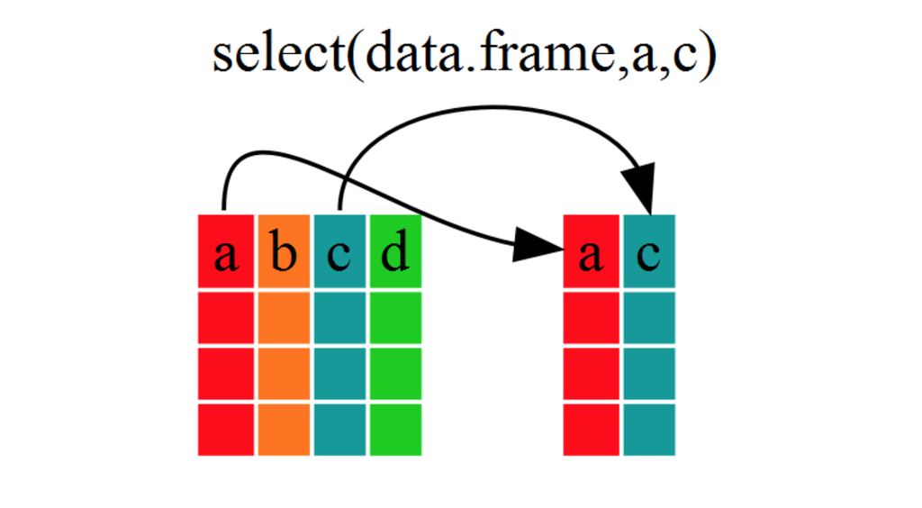

$~$

#### 5.2 The Pipe

$~$

[figure not shown]

$~$

Above, we used what’s called ‘normal’ grammar, but the strengths of `dplyr` lie in combining several functions using pipes. Since the pipes grammar is unlike anything we’ve seen in R before, let’s repeat what we’ve done above using pipes.

$~$

If we want to make a pizza, using typical base R code, a simple operation might be written like:

$~$

```r
pizza <- bake(top(pick(ingredients)))
# code not for running
```

$~$

A computer will understand this, but a person likes to read from left to right. So an alternative but more readable way is like:

$~$

```r
choice <- pick(ingredients)
raw <- top(choice)
pizza <- bake(raw)
# code not for running
```

$~$

But, this can clutter our environment with a lot of variables that aren’t very useful to us.

$~$

### Here comes the pipes `%>%`

$~$

The **pipe** makes it easier to read code by laying out operations from left to right – each line can be read like a line of a recipe for the perfect data frame!

$~$

Pipes take the input on the left side of the `%>%` symbol and pass it in as the first argument to the function on the right side.

$~$

With pipes, our pizza example might be written like:

$~$

```r
pizza <- ingredients %>%
  pick() %>%
  top() %>%
  bake()
# code not for running
```

$~$

In RStudio, the hotkey for the pipe is `Cmd + Shitf + M` in Mac and `Ctrl + Shift + M` in Windows.

$~$

### Combination of `select` & `%>%`

$~$

Since the pipe grammar is unlike anything we’ve seen in R before, let’s repeat what we did above with the planets dataset using pipes:

$~$

```r
planets2 <- planets %>%
  select(name, diameter_ratio)

planets2
```

$~$

Let’s walk through it step by step.

$~$

First, we summon the planets data frame and pass it on to the next step using the pipe symbol `%>%`.

$~$

Second, the `select()` function chooses the variables. In this case, we don’t specify which data object we use in the call to `select()` since we’ve piped it in from the previous line.

$~$

### 5.3 Filter Rows with `filter`

$~$

We can use `filter` to choose specific rows we want.

$~$

The syntax is `filter(.data = , condition = )`. But with the pipes, it becomes easier. For example, now let’s say we’re only interested in the name and diameter of plants without rings. We can combine select and filter to select only the observations where planets don’t have rings.

$~$

```r
planets3 <- planets %>%
  filter(rings == FALSE) %>%
  select(name, diameter_ratio)

planets3
```

$~$

**Note**: The order of operations is very important in this case. If we used select first, filter would not be able to find the variable rings since we would have removed it in the previous step.

$~$

### 5.4 Add New Variables with `mutate`

$~$

We can use `mutate()` to add new variables and preserves existing ones. For example, we want to round the “diameter_ratio” to 2 decimals, we can do as follows:

$~$

```r
planets4 <- planets %>%
  mutate(diameter_ratio2 = round(diameter_ratio, 2))

planets4
```

$~$

You can also use `mutate()` to change the values of variables. For example, we want to create a new variable that shows the volume of each planet. (The radius of Earth is about 4,000 miles. Recall, the formula for the volume of a sphere is $V = \frac{4}{3} \pi r^2$)

$~$

```r
planets5 <- planets %>%
  mutate(radius = 4000 * diameter_ratio) %>%
  mutate(volume = (4 / 3) * pi * (radius ^ 2))

planets5
```

$~$

**Note**, we use `=` to link the new variable name and its value.

$~$

### 5.5 Add Variables with Conditions by Using `ifelse` Function

$~$

`mutate()` is always used with `ifelse` function. `ifelse` is a base R function. The usage for `ifelse` function is that `ifelse(test, yes, no)`.

$~$

For example, we want to generate a dummy variable (with the value of 0 or 1) that indicates the Earth, we can write like this:

$~$

```r
# ifelse will return a vector that identifies earth as 1, and 0 otherwise
ifelse(planets$name == "Earth", 1, 0)
```

```
## [1] 0 0 1 0 0 0 0 0
```

$~$

```r
planets6 <- planets %>%
  mutate(earth = ifelse(name == "Earth", 1, 0))

planets6
```

```
##      name               type diameter_ratio rings earth
## 1 Mercury Terrestrial planet          0.382 FALSE     0
## 2   Venus Terrestrial planet          0.949 FALSE     0
## 3   Earth Terrestrial planet          1.000 FALSE     1
## 4    Mars Terrestrial planet          0.532 FALSE     0
## 5 Jupiter          Gas giant         11.209  TRUE     0
## 6  Saturn          Gas giant          9.449  TRUE     0
## 7  Uranus          Gas giant          4.007  TRUE     0
## 8 Neptune          Gas giant          3.883  TRUE     0
```

$~$

And, as you may have noticed, since we have pipes, we don’t have to type `planet$`. See, pipes really make our code easy to read and succinct.

$~$

We can also use `ifelse` multiple times. For example, if my favorite is gas giant planet with a diameter smaller than 5.

$~$

```r
planets7 <- planets %>%
  mutate(favorite = ifelse(type == "Gas giant", ifelse(diameter < 5, 1, 0), 0))

planets7
```

$~$

#### Challenge

$~$

- Use `mutate()` and `ifelse` to generate a new variable, named “best”, which is 1 if it doesn’t have a ring and its diameter_ratio is larger than 0.5, and is 0 otherwise.

$~$